# 2026-05-12_SUN4_UTR_flow

Benny Kleinerman

2026-05-12

Summary: Analysis of the flow cytometry data gathered 2025-09-04, on Sun4-mNeonGreen reporter strains with modified UTRs.

# Define functions to load flow cytometry data, using FlowCore package

```r
repair_flow_colnames <- function(string) {
  string %>%
    stringr::str_replace_all(" ", "") %>%
    stringr::str_replace_all("PE-", "PE") %>%
    stringr::str_replace_all("-", "_")
}

read_fcs_tibble <- function(file,...) {
  read.FCS(file,...) %>%
    .@exprs %>%
    as_tibble %>%
    set_names(repair_flow_colnames(names(.)))
}
```

# Describe the data

First we load the sample sheet, that describes the sample contents and filenames.

We also make some of the data factors in the desired order, and create a “BioRep” (biological replicate) column from the strain ID.

```r
datadir <- here::here("2025-09-04_SUN4-mNG_flow")

samplesheet <- paste(datadir, "/2025-09-04_SUN4-mNG_flowplan.xlsx", sep = "") %>%
  readxl::read_excel(skip = 5) %>%
  mutate(Five_prime_UTR = factor(Five_prime_UTR, levels = rev(c(
        "SUN4",
        "xintless",
        "delSBM1x",
        "delSBM12x",
        "delSBMregx",
        "mutSBM1x",
        "mutSBM12x",
        "mutSBM12altx",
        "PGK1"))),
      Five_prime_UTR_hr = forcats::fct_recode(Five_prime_UTR,
        "Native (no intron)" = "xintless",
        "Del-1" = "delSBM1x",
        "Del-2" = "delSBM12x",
        "Del-3" = "delSBMregx",
        "Sub-1" = "mutSBM1x",
        "Sub-2" = "mutSBM12x",
        "Sub-3" = "mutSBM12altx"), # I manually annotate my plots with these anyway, this just helps with that
      Background = factor(Background, levels = c("Wild Type", "ssd1Δ")),
      Techrep = factor(Techrep))

print(samplesheet, n = 19)
```

```
## # A tibble: 70 × 11
##    Sample ID     Techrep Construct     Background Five_prime_UTR Three_prime_UTR
##     <dbl> <chr>  <fct>   <chr>         <fct>      <fct>          <chr>
##  1      1 yMJ003 1       fSUN4-SUN4-m… Wild Type  SUN4           ADH1
##  2      2 yMJ003 2       fSUN4-SUN4-m… Wild Type  SUN4           ADH1
##  3      3 yMJ003 3       fSUN4-SUN4-m… Wild Type  SUN4           ADH1
##  4      4 yBK023 1       fxintless-SU… Wild Type  xintless       ADH1
##  5      5 yBK023 2       fxintless-SU… Wild Type  xintless       ADH1
##  6      6 yBK023 3       fxintless-SU… Wild Type  xintless       ADH1
##  7      7 yBK054 1       fmutSBM1x-SU… Wild Type  mutSBM1x       ADH1
##  8      8 yBK054 2       fmutSBM1x-SU… Wild Type  mutSBM1x       ADH1
##  9      9 yBK054 3       fmutSBM1x-SU… Wild Type  mutSBM1x       ADH1
## 10     10 yBK026 1       fmutSBM12x-S… Wild Type  mutSBM12x      ADH1
## 11     11 yBK026 2       fmutSBM12x-S… Wild Type  mutSBM12x      ADH1
## 12     12 yBK026 3       fmutSBM12x-S… Wild Type  mutSBM12x      ADH1
## 13     13 yBK056 1       fmutSBM12alt… Wild Type  mutSBM12altx   ADH1
## 14     14 yBK056 2       fmutSBM12alt… Wild Type  mutSBM12altx   ADH1
## 15     15 yBK056 3       fmutSBM12alt… Wild Type  mutSBM12altx   ADH1
## 16     16 yBK014 1       fdelSBM1x-SU… Wild Type  delSBM1x       ADH1
## 17     17 yBK014 2       fdelSBM1x-SU… Wild Type  delSBM1x       ADH1
## 18     18 yBK014 3       fdelSBM1x-SU… Wild Type  delSBM1x       ADH1
## 19     19 yBK017 1       fdelSBM12x-S… Wild Type  delSBM12x      ADH1
## # ℹ 51 more rows
## # ℹ 4 more variables: Stain <chr>, Code <chr>, Filename <chr>,
## #   Five_prime_UTR_hr <fct>
```

# Load all the data

Next we load the data from all those files.

```r
flow_data_all <- samplesheet %>%
  group_by(Sample, ID, Techrep, Construct, Background, Five_prime_UTR, Five_prime_UTR_hr, Three_prime_UTR, Stain, Code, Filename) %>%
  do( read_fcs_tibble(paste(datadir, .$Filename[1], sep = "/")) )
```

# Gate data for singlets

```r
# Gate containing budded singlet cells, as identified by imaging flow cytometry
flow_data_gated_buddedsinglets <- flow_data_all %>%
  dplyr::filter(FSC_H > 45000, FSC_H < 90000,
                FSC_W > 64000, FSC_W < 72000)
```

### Calculate the proportion of gated events

```r
flow_data_all
```

```
## # A tibble: 1,158,284 × 37
## # Groups:   Sample, ID, Techrep, Construct, Background, Five_prime_UTR,
## #   Five_prime_UTR_hr, Three_prime_UTR, Stain, Code, Filename [70]
##    Sample ID     Techrep Construct   Background Five_prime_UTR Five_prime_UTR_hr
##     <dbl> <chr>  <fct>   <chr>       <fct>      <fct>          <fct>
##  1      1 yMJ003 1       fSUN4-SUN4… Wild Type  SUN4           SUN4
##  2      1 yMJ003 1       fSUN4-SUN4… Wild Type  SUN4           SUN4
##  3      1 yMJ003 1       fSUN4-SUN4… Wild Type  SUN4           SUN4
##  4      1 yMJ003 1       fSUN4-SUN4… Wild Type  SUN4           SUN4
##  5      1 yMJ003 1       fSUN4-SUN4… Wild Type  SUN4           SUN4
##  6      1 yMJ003 1       fSUN4-SUN4… Wild Type  SUN4           SUN4
##  7      1 yMJ003 1       fSUN4-SUN4… Wild Type  SUN4           SUN4
##  8      1 yMJ003 1       fSUN4-SUN4… Wild Type  SUN4           SUN4
##  9      1 yMJ003 1       fSUN4-SUN4… Wild Type  SUN4           SUN4
## 10      1 yMJ003 1       fSUN4-SUN4… Wild Type  SUN4           SUN4
## # ℹ 1,158,274 more rows
## # ℹ 30 more variables: Three_prime_UTR <chr>, Stain <chr>, Code <chr>,
## #   Filename <chr>, FSC_A <dbl>, FSC_H <dbl>, FSC_W <dbl>, SSC_A <dbl>,
## #   SSC_H <dbl>, SSC_W <dbl>, FITC_A <dbl>, FITC_W <dbl>, PerCP_Cy5_5_A <dbl>,
## #   APC_A <dbl>, AlexaFluor700_A <dbl>, APC_Cy7_A <dbl>, BV421_A <dbl>,
## #   AmCyan_A <dbl>, BV605_A <dbl>, BV650_A <dbl>, BV711_A <dbl>, BV786_A <dbl>,
## #   PEA <dbl>, PETexasRed_A <dbl>, PETexasRed_W <dbl>, PECy5_A <dbl>, …
```

```r
flow_count_gates <-
  left_join(flow_data_all %>%
              group_by(Filename, ID, Construct, Stain, Code) %>%
              tally(),
            flow_data_gated_buddedsinglets %>%
              group_by(Filename, ID, Construct, Stain, Code) %>%
              tally(),
            by = c("Filename","ID","Construct","Stain", "Code"),
            suffix = c("_all", "_gated") ) %>%
  mutate(prop_gated = n_gated / n_all)

print(flow_count_gates, n = 19)
```

```
## # A tibble: 70 × 8
## # Groups:   Filename, ID, Construct, Stain [70]
##    Filename                 ID    Construct Stain Code  n_all n_gated prop_gated
##    <chr>                    <chr> <chr>     <chr> <chr> <int>   <int>      <dbl>
##  1 Specimen_001_A10_A10_01… yBK0… fmutSBM1… Dual  Moti… 31399    7860      0.250
##  2 Specimen_001_A11_A11_01… yBK0… fmutSBM1… Dual  Moti… 31744    7571      0.239
##  3 Specimen_001_A12_A12_01… yBK0… fmutSBM1… Dual  Moti… 32035    7828      0.244
##  4 Specimen_001_A1_A01_001… yMJ0… fSUN4-SU… Dual  Nati… 31357    6993      0.223
##  5 Specimen_001_A2_A02_002… yMJ0… fSUN4-SU… Dual  Nati… 31489    7320      0.232
##  6 Specimen_001_A3_A03_003… yMJ0… fSUN4-SU… Dual  Nati… 52444   12295      0.234
##  7 Specimen_001_A4_A04_004… yBK0… fxintles… Dual  Intr… 52200   11923      0.228
##  8 Specimen_001_A5_A05_005… yBK0… fxintles… Dual  Intr… 52873   12752      0.241
##  9 Specimen_001_A6_A06_006… yBK0… fxintles… Dual  Intr… 31627    7337      0.232
## 10 Specimen_001_A7_A07_007… yBK0… fmutSBM1… Dual  Moti… 32098    8247      0.257
## 11 Specimen_001_A8_A08_008… yBK0… fmutSBM1… Dual  Moti… 53131   11713      0.220
## 12 Specimen_001_A9_A09_009… yBK0… fmutSBM1… Dual  Moti… 31502    8285      0.263
## 13 Specimen_002_B1_B01_013… yBK0… fmutSBM1… Dual  Moti… 31458    6313      0.201
## 14 Specimen_002_B2_B02_014… yBK0… fmutSBM1… Dual  Moti… 31925    8880      0.278
## 15 Specimen_002_B3_B03_015… yBK0… fmutSBM1… Dual  Moti… 31352    6952      0.222
## 16 Specimen_003_B10_B10_02… yBK0… fdelSBMr… Dual  Moti… 10461    2449      0.234
## 17 Specimen_003_B11_B11_02… yBK0… fdelSBMr… Dual  Moti… 10448    2317      0.222
## 18 Specimen_003_B12_B12_02… yBK0… fdelSBMr… Dual  Moti… 10864    1832      0.169
## 19 Specimen_003_B4_B04_016… yBK0… fdelSBM1… Dual  Moti… 10460    2620      0.250
## # ℹ 51 more rows
```

Samples still have thousands of events after gating

# Comparing forward scatter height (FSC_H) with forward scatter width (FSC_W) to display the gating strategy

## Wild Type

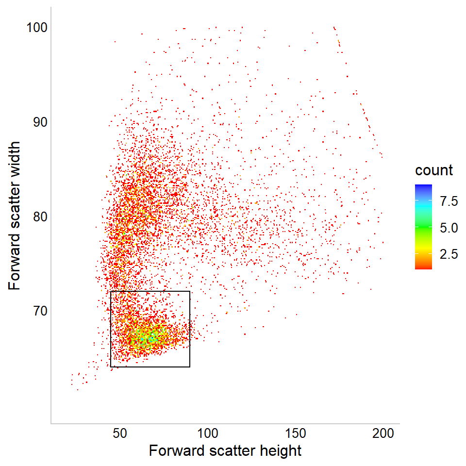

```r
fsc_wt <- ggplot(
  data = dplyr::filter(flow_data_all, Code == "Native5UTR_Nativeterm_Wildtype", Techrep == 2), # Wild type reporter strain
  aes(x = FSC_H, y = FSC_W)) +
  geom_hex(bins = 300) +
  scale_fill_gradientn(colours = rainbow(6)[1:5]) +
  theme(
    text = element_text(family = "sans"),
    axis.line = element_line(colour = "grey80"),
    axis.ticks = element_blank()) +
  labs(x = "Forward scatter height", y = "Forward scatter width") +
  scale_x_continuous(
    limits = c(20000, 200000),
    breaks = c(50000, 100000, 150000, 200000),
    labels = c("50", "100", "150", "200")) +
  scale_y_continuous(
    limits = c(60000, 100000),
    breaks = c(70000, 80000, 90000, 100000),
    labels = c("70", "80", "90", "100")) +
  geom_rect(
    xmin = 45000,
    xmax = 90000,
    ymin = 64000,
    ymax = 72000,
    fill = NA,
    colour = "black",
    linewidth = 0.5) # overlays a rectangle on the plot, indicating gating strategy

fsc_wt
```

## ssd1Δ

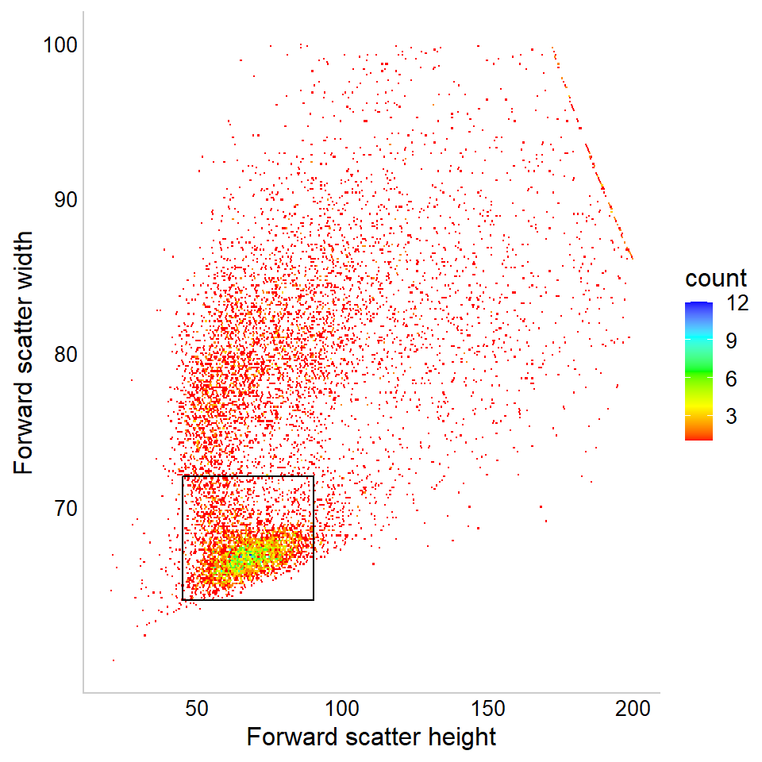

```r
fsc_delta <- ggplot(
  data = dplyr::filter(flow_data_all, Code == "Native5UTR_Nativeterm_ssd1Δ", Techrep == 1), # ssd1Δ reporter strain, techrep 1
  aes(x = FSC_H, y = FSC_W)) +
  geom_hex(bins = 300) +
  scale_fill_gradientn(colours = rainbow(6)[1:5]) +
  theme(
    text = element_text(family = "sans"),
    axis.line = element_line(colour = "grey80"),
    axis.ticks = element_blank()) +
  labs(x = "Forward scatter height", y = "Forward scatter width") +
  scale_x_continuous(
    limits = c(20000, 200000),
    breaks = c(50000, 100000, 150000, 200000),
    labels = c("50", "100", "150", "200")) +
  scale_y_continuous(
    limits = c(60000, 100000),
    breaks = c(70000, 80000, 90000, 100000),
    labels = c("70", "80", "90", "100")) +
  geom_rect(
    xmin = 45000,
    xmax = 90000,
    ymin = 64000,
    ymax = 72000,
    fill = NA,
    colour = "black",
    linewidth = 0.5)

fsc_delta
```

# Compare mNeonGreen (FITC) signal with FSC_A (forward scatter area), to justify using FSC as a normalisation strategy.

## filter the singlets gated dataset for swapped UTR strains first

```r
flow_data_gated_buddedsinglets_utrs <- flow_data_gated_buddedsinglets %>%
  dplyr::filter(
    Construct %in% c(
      "fSUN4-SUN4-mNG-tADH1",
      "fPGK1-SUN4-mNG-tADH1",
      "fSUN4-SUN4-mNG-tSUN4",
      "fPGK1-SUN4-mNG-tSUN4",
      "fxintless-SUN4-mNG-tADH1"), # filter for constructs with intact UTRs
    !stringr::str_detect(Code, "control")) %>% # exclude unstained controls
  mutate(Construct_hr = interaction(Five_prime_UTR, Three_prime_UTR) %>%
           factor(
             levels = c(
               "PGK1.ADH1",
               "xintless.ADH1",
               "SUN4.ADH1",
               "PGK1.SUN4",
               "SUN4.SUN4"),
             labels = c(
               "PGK1  ADH1",
               "SUN4 (no intron)  ADH1",
               "SUN4  ADH1",
               "PGK1  SUN4",
               "SUN4  SUN4"))) %>% # Create levels and labels for ridge plot
  mutate(Strain = interaction(Five_prime_UTR, Three_prime_UTR, Background) %>%
           factor(levels = rev(
             c("PGK1.ADH1.ssd1Δ",
               "PGK1.ADH1.Wild Type",
               "xintless.ADH1.ssd1Δ",
               "xintless.ADH1.Wild Type",
               "SUN4.ADH1.ssd1Δ",
               "SUN4.ADH1.Wild Type",
               "PGK1.SUN4.ssd1Δ",
               "PGK1.SUN4.Wild Type",
               "SUN4.SUN4.ssd1Δ",
               "SUN4.SUN4.Wild Type")))) # Create levels for faceted plot below
```

### plot mNeonGreen vs FSC area for the intact UTR strains, gated for singlets

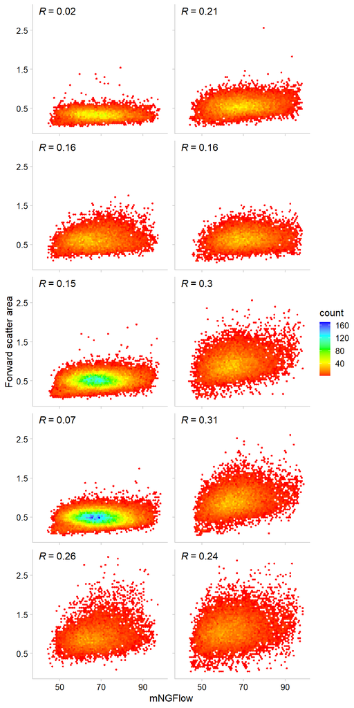

```r
mng_fsc_utr_singlets <- ggplot(
  data = flow_data_gated_buddedsinglets_utrs,
  aes(x = FSC_A, y = FITC_A)) +
  geom_hex(bins = 64) +
  scale_fill_gradientn(colours = rainbow(6)[1:5]) +
  stat_cor(
    method = "pearson",
    aes(label = ..r.label..),
    label.sep = "",
    r.accuracy = 0.01,
    label.x = 40000,
    label.y = 3000) + # annotates with pearson R value
  ggh4x::facet_wrap2(
  ~ Strain,
  scales = "fixed",
  ncol = 2,
  axes = "all",
  remove_labels = "all") +
  labs(x = "mNGFlow", y = "Forward scatter area") +
  theme(text = element_text(family = "sans"),
        axis.line = element_line(colour= "grey80"),
        axis.ticks = element_line(colour = "grey80"),
        strip.text = element_blank()) +
  scale_x_continuous(breaks = c(50000, 70000, 90000),
                     labels = c("50", "70", "90")) +
  scale_y_continuous(limits = c(0, 3000),
                     breaks = c(500, 1500, 2500),
                     labels = c("0.5", "1.5", "2.5"))

mng_fsc_utr_singlets
```

R is between 0.02 and 0.31, for these strains

## filter the ungated dataset for intact UTR strains.

```r
flow_data_utr <- flow_data_all %>%
  dplyr::filter(
    Construct %in% c(
      "fSUN4-SUN4-mNG-tADH1",
      "fPGK1-SUN4-mNG-tADH1",
      "fSUN4-SUN4-mNG-tSUN4",
      "fPGK1-SUN4-mNG-tSUN4",
      "fxintless-SUN4-mNG-tADH1"),
    !stringr::str_detect(Code, "control")) %>% # exclude unstained controls
  mutate(Construct_hr = interaction(Five_prime_UTR, Three_prime_UTR) %>%
           factor(levels = c(
               "PGK1.ADH1",
               "xintless.ADH1",
               "SUN4.ADH1",
               "PGK1.SUN4",
               "SUN4.SUN4"))) %>%
  mutate(Strain = interaction(Five_prime_UTR, Three_prime_UTR, Background) %>%
           factor(levels = rev(c(
               "PGK1.ADH1.ssd1Δ",
               "PGK1.ADH1.Wild Type",
               "xintless.ADH1.ssd1Δ",
               "xintless.ADH1.Wild Type",
               "SUN4.ADH1.ssd1Δ",
               "SUN4.ADH1.Wild Type",
               "PGK1.SUN4.ssd1Δ",
               "PGK1.SUN4.Wild Type",
               "SUN4.SUN4.ssd1Δ",
               "SUN4.SUN4.Wild Type"))))
```

### plot mNeonGreen vs FSC for this dataset

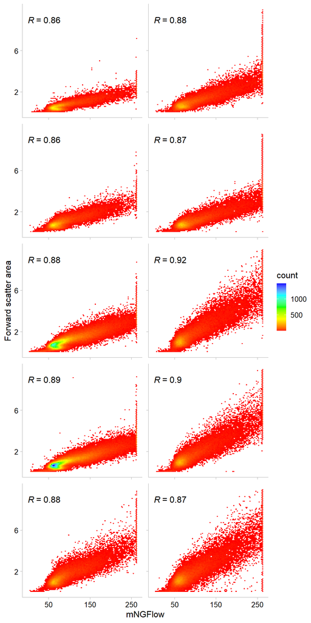

```r
mng_fsc_utr <- ggplot(
  data = flow_data_utr,
  aes(x = FSC_A, y = FITC_A)) +
  geom_hex(bins = 100) +
  scale_fill_gradientn(colours = rainbow(6)[1:5]) +
  stat_cor(
    method = "pearson",
    aes(label = ..r.label..),
    label.sep = "",
    r.accuracy = 0.01,
    label.x = 0,
    label.y = 9000) + # annotates with pearson R value
  ggh4x::facet_wrap2(
  ~ Strain,
  scales = "fixed",
  ncol = 2,
  axes = "all",
  remove_labels = "all") +
  labs(x = "mNGFlow", y = "Forward scatter area") +
  theme(text = element_text(family = "sans"),
        axis.line = element_line(colour= "grey80"),
        axis.ticks = element_line(colour = "grey80"),
        strip.text = element_blank()) +
  scale_x_continuous(breaks = c(50000,150000,250000),
                     labels = c("50", "150", "250")) +
  scale_y_continuous(limits = c(0, 10000),
                     breaks = c(2000, 6000),
                     labels = c("2", "6"))

mng_fsc_utr
```

R is much higher when not gating. Number of cells per event or cluster scales well with mNeonGreen intensity

## filter the singlet dataset for strains with ADH1 terminator

```r
flow_data_gated_buddedsinglets_tadh1 <-
  flow_data_gated_buddedsinglets %>%
  dplyr::filter(
    Three_prime_UTR == "ADH1",
    !stringr::str_detect(Code, "control"), # exclude no stain samples
    !Five_prime_UTR %in% c("PGK1", "SUN4")) %>% # exclude these because they are included in the swapped UTRs plot
  mutate(Strain = factor(interaction(Five_prime_UTR, Background), levels = c(
          "xintless.Wild Type",
          "xintless.ssd1Δ",
          "delSBM1x.Wild Type",
          "delSBM1x.ssd1Δ",
          "delSBM12x.Wild Type",
          "delSBM12x.ssd1Δ",
          "delSBMregx.Wild Type",
          "delSBMregx.ssd1Δ",
          "mutSBM1x.Wild Type",
          "mutSBM1x.ssd1Δ",
          "mutSBM12x.Wild Type",
          "mutSBM12x.ssd1Δ",
          "mutSBM12altx.Wild Type",
          "mutSBM12altx.ssd1Δ")))
```

### plot mNeonGreen vs FSC for this dataset

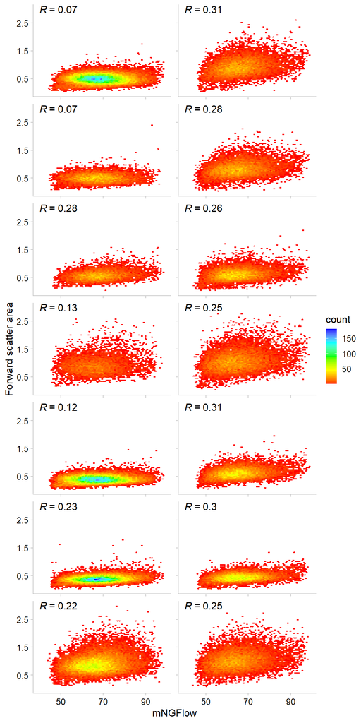

```r
mng_fsc_tadh1_singlets <- ggplot(
  data = flow_data_gated_buddedsinglets_tadh1,
  aes(x = FSC_A, y = FITC_A)) +
  geom_hex(bins = 64) +
  scale_fill_gradientn(colours = rainbow(6)[1:5]) +
  stat_cor(
    method = "pearson",
    aes(label = ..r.label..),
    label.sep = "",
    r.accuracy = 0.01,
    label.x = 40000,
    label.y = 3000) + # annotates with pearson R value
  ggh4x::facet_wrap2(
  ~ Strain,
  scales = "fixed",
  ncol = 2,
  axes = "all",
  remove_labels = "all") +
  labs(x = "mNGFlow", y = "Forward scatter area") +
  theme(text = element_text(family = "sans"),
        axis.line = element_line(colour= "grey80"),
        axis.ticks = element_line(colour = "grey80"),
        strip.text = element_blank()) +
  scale_x_continuous(breaks = c(50000, 70000, 90000),
                     labels = c("50", "70", "90")) +
  scale_y_continuous(limits = c(0, 3000),
                     breaks = c(500, 1500, 2500),
                     labels = c("0.5", "1.5", "2.5"))

mng_fsc_tadh1_singlets
```

R is similarly low for these strains

## filter the ungated dataset for strains with ADH1 terminator

```r
flow_data_all_tadh1 <-
  flow_data_all %>%
  dplyr::filter(
    Three_prime_UTR == "ADH1",
    !stringr::str_detect(Code, "control"), # exclude no stain samples
    !Five_prime_UTR %in% c("PGK1", "SUN4")) %>% # exclude these because they are included in the swapped UTRs plot
  mutate(Strain = factor(interaction(Five_prime_UTR, Background), levels = c(
          "xintless.Wild Type",
          "xintless.ssd1Δ",
          "delSBM1x.Wild Type",
          "delSBM1x.ssd1Δ",
          "delSBM12x.Wild Type",
          "delSBM12x.ssd1Δ",
          "delSBMregx.Wild Type",
          "delSBMregx.ssd1Δ",
          "mutSBM1x.Wild Type",
          "mutSBM1x.ssd1Δ",
          "mutSBM12x.Wild Type",
          "mutSBM12x.ssd1Δ",
          "mutSBM12altx.Wild Type",
          "mutSBM12altx.ssd1Δ")))
```

### plot mNeonGreen vs FSC for this dataset

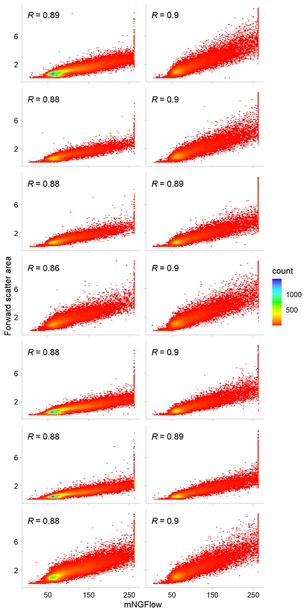

```r
mng_fsc_tadh1 <- ggplot(
  data = flow_data_all_tadh1,
  aes(x = FSC_A, y = FITC_A)) +
  geom_hex(bins = 100) +
  scale_fill_gradientn(colours = rainbow(6)[1:5]) +
  stat_cor(
    method = "pearson",
    aes(label = ..r.label..),
    label.sep = "",
    r.accuracy = 0.01,
    label.x = 0,
    label.y = 9000) + # annotates with pearson R value
  ggh4x::facet_wrap2(
  ~ Strain,
  scales = "fixed",
  ncol = 2,
  axes = "all",
  remove_labels = "all") +
  labs(x = "mNGFlow", y = "Forward scatter area") +
  theme(text = element_text(family = "sans"),
        axis.line = element_line(colour= "grey80"),
        axis.ticks = element_line(colour = "grey80"),
        strip.text = element_blank()) +
  scale_x_continuous(breaks = c(50000,150000,250000),
                     labels = c("50", "150", "250")) +
  scale_y_continuous(limits = c(0, 10000),
                     breaks = c(2000, 6000),
                     labels = c("2", "6"))

mng_fsc_tadh1
```

R is similarly high for these strains

# Ridgeplots of intact UTR strains, and mutated 5 prime UTR strains

## Intact UTRs first

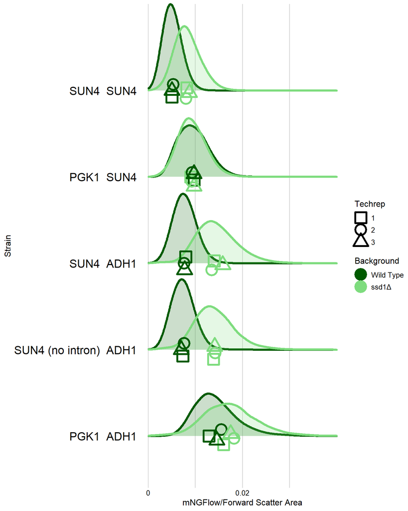

```r
mng_singlets_utr <- ggplot(data = flow_data_gated_buddedsinglets_utrs, aes(
  x = FITC_A / FSC_A, y = Construct_hr, colour = Background)) +
  stat_density_ridges(
    scale = 1,
    linewidth = 1.5,
    alpha = 0.2,
    bandwidth = 0.001,
    aes(fill = Background),
    show.legend = FALSE) +
  stat_summary(aes(
      group = interaction(Code, Techrep),
      shape = Techrep,
      colour = Background),
    fun = mean,
    geom = "point",
    size = 6,
    stroke = 2,
    position = position_quasirandom(groupOnX = FALSE, width = 0.15)) + # plots means for each replicate as different shapes, coloured by Background
  labs(x = "mNGFlow/Forward Scatter Area", y = "Strain") +
  theme(
    panel.grid.major.x = element_line(colour = "grey80"),
    axis.line = element_blank(),
    axis.ticks = element_blank(),
    axis.text.y = element_text(size = 16)) +
  coord_cartesian(expand = TRUE, clip = 'off') +
  scale_x_continuous(
    limits = c(0.0, 0.04),
    breaks = c(0, 0.01, 0.02, 0.03),
    labels = c("0", "", "0.02", "")) +
  scale_colour_manual(values = c("#005a00ff", "#7edc7eff")) +
  scale_fill_manual(values = c("#005a0033", "#7edc7e33")) + # These colours will change
  scale_shape_manual(values = c(0, 1, 2))

mng_singlets_utr
```

## Ridgeplot of mutant 5 prime UTR strains

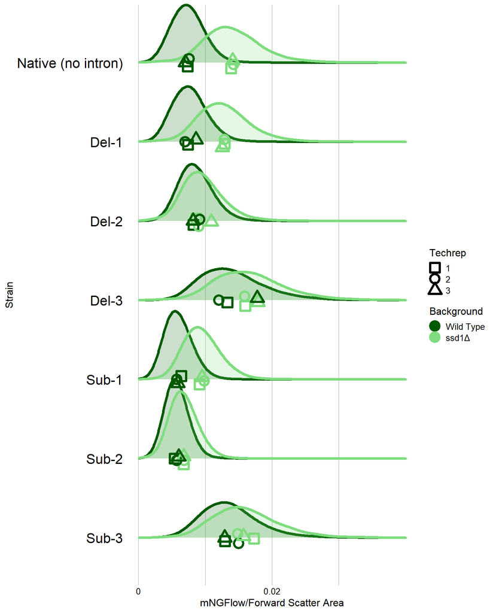

```r
mng_singlets_tadh1 <- ggplot(data = flow_data_gated_buddedsinglets_tadh1, aes(
  x = FITC_A / FSC_A, y = Five_prime_UTR_hr, colour = Background)) +
  stat_density_ridges(
    scale = 1,
    linewidth = 1.5,
    alpha = 0.2,
    bandwidth = 0.001,
    aes(fill = Background),
    show.legend = FALSE) +
  stat_summary(aes(
      group = interaction(Code, Techrep),
      shape = Techrep,
      colour = Background),
    fun = mean,
    geom = "point",
    size = 4,
    stroke = 2,
    position = position_quasirandom(groupOnX = FALSE, width = 0.1)) +
  labs(x = "mNGFlow/Forward Scatter Area", y = "Strain") +
  theme(
    panel.grid.major.x = element_line(colour = "grey80"),
    axis.line = element_blank(),
    axis.ticks = element_blank(),
    axis.text.y = element_text(size = 16)) +
  coord_cartesian(expand = TRUE, clip = 'off') +
  scale_x_continuous(
    limits = c(0.0, 0.04),
    breaks = c(0, 0.01, 0.02, 0.03),
    labels = c("0", "", "0.02", "")) +
  scale_colour_manual(values = c("#005a00ff", "#7edc7eff")) +
  scale_fill_manual(values = c("#005a0033", "#7edc7e33")) +
  scale_shape_manual(values = c(0, 1, 2))

mng_singlets_tadh1
```

# Calculate linear model coefficients for mNeonGreen/FSC_A, for comparison with RT-qPCR data

# First bring in the tADH1 and whole UTR RT-qPCR coefficients

```r
fit_RTqPCR_tADH1_tsv <- read.delim(
  here::here("fit_RTqPCR_tADH1.tsv"),
  row.names = 1)

fit_RTqPCR_utrs_tsv <- read.delim(
  here::here("fit_RTqPCR_utrs.tsv"),
  row.names = 1)
```

# tADH1 strains

## Match levels and names of the tADH1 Strains to the RT-qPCR Strains

```r
flow_data_gated_buddedsinglets_tadh1 <-
  flow_data_gated_buddedsinglets_tadh1 %>%
  mutate(Strain = factor(Strain, levels = c(
      "xintless.Wild Type",
      "mutSBM12altx.Wild Type",
      "mutSBM12x.Wild Type",
      "mutSBM1x.Wild Type",
      "delSBMregx.Wild Type",
      "delSBM12x.Wild Type",
      "delSBM1x.Wild Type",
      "mutSBM12altx.ssd1Δ",
      "mutSBM12x.ssd1Δ",
      "mutSBM1x.ssd1Δ",
      "delSBMregx.ssd1Δ",
      "delSBM12x.ssd1Δ",
      "delSBM1x.ssd1Δ",
      "xintless.ssd1Δ")),
    Strain = forcats::fct_recode(Strain,
      "Native (no intron).Wild Type" = "xintless.Wild Type",
      "Sub-3.Wild Type" = "mutSBM12altx.Wild Type",
      "Sub-2.Wild Type" = "mutSBM12x.Wild Type",
      "Sub-1.Wild Type" = "mutSBM1x.Wild Type",
      "Del-3.Wild Type" = "delSBMregx.Wild Type",
      "Del-2.Wild Type" = "delSBM12x.Wild Type",
      "Del-1.Wild Type" = "delSBM1x.Wild Type",
      "Sub-3.ssd1delta" = "mutSBM12altx.ssd1Δ",
      "Sub-2.ssd1delta" = "mutSBM12x.ssd1Δ",
      "Sub-1.ssd1delta" = "mutSBM1x.ssd1Δ",
      "Del-3.ssd1delta" = "delSBMregx.ssd1Δ",
      "Del-2.ssd1delta" = "delSBM12x.ssd1Δ",
      "Del-1.ssd1delta" = "delSBM1x.ssd1Δ",
      "Native (no intron).ssd1delta" = "xintless.ssd1Δ"))
```

## Fit a log10 linear model to the tADH1 dataset that uses 0 as the intercept (to calculate Strain means)

```r
fit_FITC_tADH1 <- lm(log10(FITC_A/FSC_A) ~ 0 + Strain,
   data = flow_data_gated_buddedsinglets_tadh1)
```

## Plot tADH1 flow cytometry coefficients against tADH1 RT-qPCR coefficients

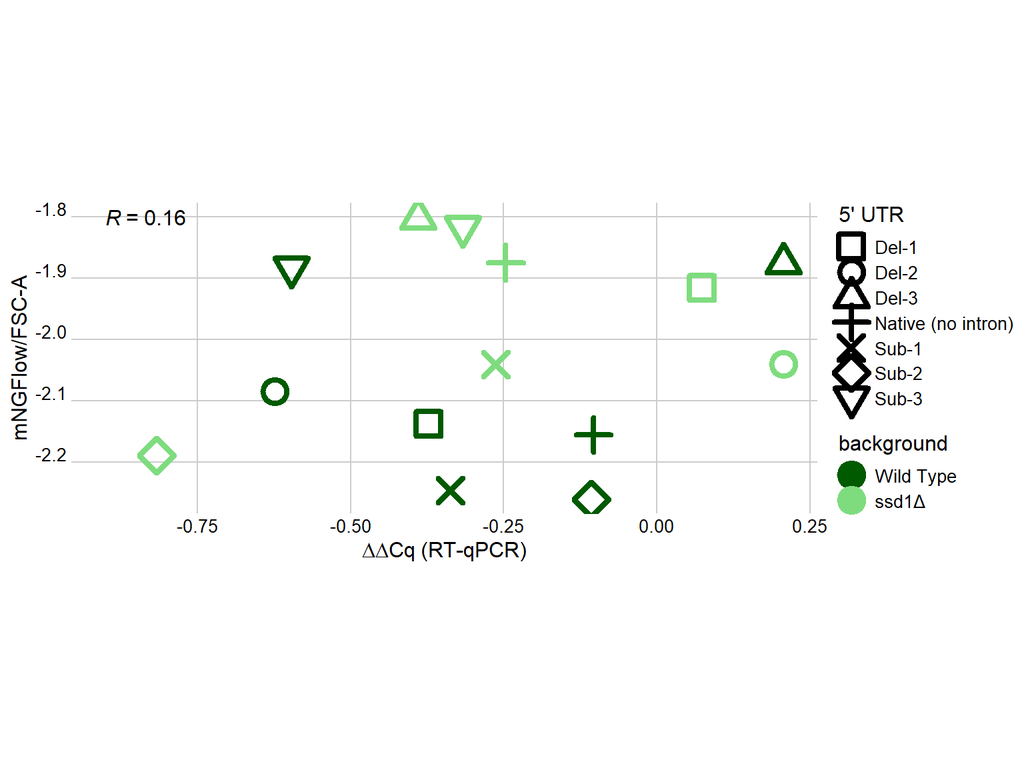

```r
# Inner join the RT-qPCR and flow coefficients into a table

coeff_tADH1 <- enframe(
  fit_FITC_tADH1$coefficients,
  name = "Strain",
  value = "FITC_coef") %>%
  inner_join(
    tibble(
      Strain = rownames(fit_RTqPCR_tADH1_tsv),
      qPCR_coef = fit_RTqPCR_tADH1_tsv$Estimate),
    by = "Strain") %>%
  mutate(
  background = str_extract(Strain, "[^.]+$"),
  background = factor(background,
                      levels = c("Wild Type", "ssd1delta"),
                      labels = c("Wild Type", "ssd1Δ")),
  UTRcombo = str_extract(Strain, ".*(?=\\.[^.]+$)"),
  UTRcombo = sub("^Strain", "", UTRcombo))

# Plot the RT-qPCR coefficients against the flow coefficients

FITC_RTqPCR <- ggplot(coeff_tADH1, aes(x = qPCR_coef, y = FITC_coef)) +
  geom_point(aes(colour = background, shape = UTRcombo), stroke = 2.25, size = 5) +
  scale_y_continuous() +
  scale_x_continuous() +
  coord_equal() +
  theme(panel.grid.major.x = element_line(colour= "grey80"),
        panel.grid.major.y = element_line(colour= "grey80"),
        axis.line = element_blank(),
        axis.ticks = element_blank(),
        axis.text.y = element_text(vjust = -0.1)) +
  stat_cor(
    method = "pearson",
    aes(label = ..r.label..),
    label.sep = "",
    r.accuracy = 0.01,
    label.x = -0.9,
    label.y = -1.8) + # annotates with pearson R value
  guides(shape=guide_legend(ncol=1)) +
  labs(shape = "5' UTR", y = "mNGFlow/FSC-A", x = expression(Delta * Delta * Cq ~ "(RT-qPCR)")) +
  scale_colour_manual(values = c("#005a00ff", "#7edc7eff")) +
  scale_fill_manual(values = c("#005a0033", "#7edc7e33")) +
  scale_shape_manual(values = c(0:6))+
  theme(legend.position = "right") # for reference

FITC_RTqPCR
```

Little correlation

## Fit a log10 linear model to the tADH1 data that uses the no intron strain as reference, to calculate fold changes

```r
flow_data_gated_buddedsinglets_tadh1 <-
  flow_data_gated_buddedsinglets_tadh1 %>%
  dplyr::ungroup() %>%
  dplyr::mutate(Strain = relevel(as.factor(Strain), ref = "Native (no intron).Wild Type"))

fit_FITC_tADH1_diffs <- lm(
  log10(FITC_A/FSC_A) ~ Strain,
  data = flow_data_gated_buddedsinglets_tadh1)

foldchange_FITC_tADH1_diffs <- 10^{ coef(fit_FITC_tADH1_diffs)[-1] }
foldchange_FITC_tADH1_diffs
```

```
##              StrainSub-3.Wild Type              StrainSub-2.Wild Type
##                          1.8712152                          0.7840190
##              StrainSub-1.Wild Type              StrainDel-3.Wild Type
##                          0.8105400                          1.9039498
##              StrainDel-2.Wild Type              StrainDel-1.Wild Type
##                          1.1761892                          1.0424882
##              StrainSub-3.ssd1delta              StrainSub-2.ssd1delta
##                          2.1836746                          0.9241569
##              StrainSub-1.ssd1delta              StrainDel-3.ssd1delta
##                          1.3002455                          2.2525012
##              StrainDel-2.ssd1delta              StrainDel-1.ssd1delta
##                          1.3022718                          1.7341838
## StrainNative (no intron).ssd1delta
##                          1.9094112
```

# whole UTR strains

## Match levels and names of the whole UTR Strains to the RT-qPCR Strains

```r
flow_data_gated_buddedsinglets_utrs <-
  flow_data_gated_buddedsinglets_utrs %>%
  dplyr::filter(FITC_A > 0) %>% # for calculating log10 coefficients
  mutate(Strain = factor(Strain, levels = c(
        "SUN4.SUN4.Wild Type",
        "SUN4.ADH1.Wild Type",
        "xintless.ADH1.Wild Type",
        "PGK1.ADH1.Wild Type",
        "xintless.SUN4.Wild Type",
        "PGK1.SUN4.Wild Type",
        "SUN4.ADH1.ssd1Δ",
        "xintless.ADH1.ssd1Δ",
        "PGK1.ADH1.ssd1Δ",
        "SUN4.SUN4.ssd1Δ",
        "xintless.SUN4.ssd1Δ",
        "PGK1.SUN4.ssd1Δ")),
    Strain = forcats::fct_recode(Strain,
        "WT.SUN4.Wild Type" = "SUN4.SUN4.Wild Type",
        "WT.ADH1.Wild Type" = "SUN4.ADH1.Wild Type",
        "intronless.ADH1.Wild Type" = "xintless.ADH1.Wild Type",
        "PGK1.ADH1.Wild Type" = "PGK1.ADH1.Wild Type",
        "intronless.SUN4.Wild Type" = "xintless.SUN4.Wild Type",
        "PGK1.SUN4.Wild Type" = "PGK1.SUN4.Wild Type",
        "WT.ADH1.ssd1delta" = "SUN4.ADH1.ssd1Δ",
        "intronless.ADH1.ssd1delta" = "xintless.ADH1.ssd1Δ",
        "PGK1.ADH1.ssd1delta" = "PGK1.ADH1.ssd1Δ",
        "WT.SUN4.ssd1delta" = "SUN4.SUN4.ssd1Δ",
        "intronless.SUN4.ssd1delta" = "xintless.SUN4.ssd1Δ",
        "PGK1.SUN4.ssd1delta" = "PGK1.SUN4.ssd1Δ"))
```

```r
fit_FITC_utrs <- lm(log10(FITC_A/FSC_A) ~ 0 + Strain,
   data = flow_data_gated_buddedsinglets_utrs)
```

## Plot whole UTR flow cytometry coefficients against RT-qPCR coefficients

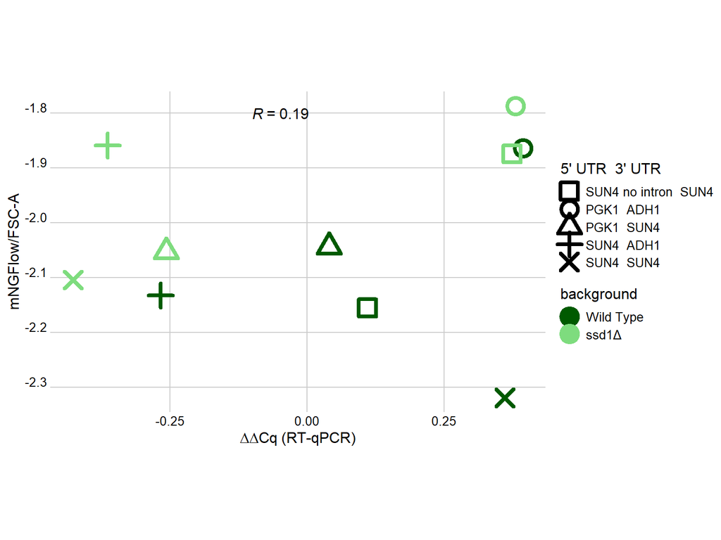

```r
coeff_utrs <- enframe(fit_FITC_utrs$coefficients,
                      name = "Strain",
                      value = "FITC_coef") %>%
  inner_join(tibble(
    Strain = rownames(fit_RTqPCR_utrs_tsv),
    qPCR_coef = fit_RTqPCR_utrs_tsv$Estimate),
  by = "Strain") %>%
  mutate(
    background = str_extract(Strain, "[^.]+$"),
    background = factor(background,
      levels = c("Wild Type", "ssd1delta"),
      labels = c("Wild Type", "ssd1Δ")),
    UTRcombo = str_extract(Strain, ".*(?=\\.[^.]+$)"),
    UTRcombo = forcats::fct_recode(
      UTRcombo,
      "SUN4  SUN4" = "StrainWT.SUN4",
      "SUN4  ADH1" = "StrainWT.ADH1",
      "SUN4 no intron  SUN4" = "Strainintronless.ADH1",
      "PGK1  ADH1" = "StrainPGK1.ADH1",
      "PGK1  SUN4" = "StrainPGK1.SUN4"))

FITC_RTqPCR_utrs <- ggplot(coeff_utrs, aes(y = FITC_coef, x = qPCR_coef)) +
  geom_point(aes(colour = background, shape = UTRcombo), stroke = 2.25, size = 5) +
  scale_y_continuous() +
  scale_x_continuous() +
  coord_equal() +
  stat_cor(
    method = "pearson",
    aes(label = ..r.label..),
    label.sep = "",
    r.accuracy = 0.01,
    label.x = -0.1,
    label.y = -1.8) + # annotates with pearson R value
  theme(panel.grid.major.x = element_line(colour= "grey80"),
        panel.grid.major.y = element_line(colour= "grey80"),
        axis.line = element_blank(),
        axis.ticks = element_blank(),
        axis.text.y = element_text(vjust = -0.1)) +
  guides(shape=guide_legend(ncol=1)) +
  labs(shape = "5' UTR  3' UTR", y = "mNGFlow/FSC-A", x = expression(Delta * Delta * Cq ~ "(RT-qPCR)")) +
  scale_colour_manual(values = c("#005a00ff", "#7edc7eff")) +
  scale_fill_manual(values = c("#005a0033", "#7edc7e33")) +
  scale_shape_manual(values = c(0:6))+
  theme(legend.position = "right") # for reference

FITC_RTqPCR_utrs
```

Little correlation

```r
flow_data_gated_buddedsinglets_utrs <-
  flow_data_gated_buddedsinglets_utrs %>%
  dplyr::ungroup() %>%
  dplyr::mutate(Strain = relevel(as.factor(Strain), ref = "WT.SUN4.Wild Type"))

fit_FITC_utrs_diffs <- lm(
  log10(FITC_A/FSC_A) ~ Strain,
  data = flow_data_gated_buddedsinglets_utrs)

foldchange_FITC_utrs_diffs <- 10^{ coef(fit_FITC_utrs_diffs)[-1] }
foldchange_FITC_utrs_diffs
```

```
##         StrainWT.ADH1.Wild Type Strainintronless.ADH1.Wild Type
##                        1.536437                        1.459012
##       StrainPGK1.ADH1.Wild Type       StrainPGK1.SUN4.Wild Type
##                        2.854202                        1.885559
##         StrainWT.ADH1.ssd1delta Strainintronless.ADH1.ssd1delta
##                        2.885559                        2.785855
##       StrainPGK1.ADH1.ssd1delta         StrainWT.SUN4.ssd1delta
##                        3.406072                        1.640197
##       StrainPGK1.SUN4.ssd1delta
##                        1.845920
```